# Predict Low Birth Weight Cases for Newborn Babies

Logistic Regression will be used to predict Low Birth Weight in infants using the remaining variables in the dataset. Low Birth Weight, the target variable, 1 = BWT <=2500g and 0 = BWT >2500g.

- Low BWT Data
- Load Libraries
- Access data
- Explore Data
- Parse Data
- Split Data into Training and Test set
- Build Logistic Regression Model
- Predict for Test data
- Evaluate the Model
- ROC curve plot

## Low BWT Data

Dataset Source: Hosmer, D.W., Lemeshow, S. and Sturdivant, R.X. (2013) Applied Logistic Regression, 3rd ed., New York: Wiley

This dataset is also part of the aplore3 R package.

[output not shown]

## Load Libraries

The Spark and Python libraries that you need are preinstalled in the notebook environment and only need to be loaded.

Run the following cell to load the libraries you will work with in this notebook:

```python
# PySpark Machine Learning Library
from pyspark.ml import Pipeline
from pyspark.ml.classification import LogisticRegression
from pyspark.ml.feature import HashingTF, Tokenizer
from pyspark.sql import Row, SQLContext

import os
import sys
from pyspark import SparkConf
from pyspark import SparkContext
from pyspark.sql import SQLContext
from pyspark.sql.types import *

from pyspark.mllib.classification import LogisticRegressionWithSGD
from pyspark.mllib.regression import LabeledPoint
from numpy import array

from pyspark.ml.evaluation import MulticlassClassificationEvaluator
# Library for confusion matrix, precision, test error
from pyspark.mllib.evaluation import MulticlassMetrics
# Library For Area under ROC curve and Area under precision-recall curve
from pyspark.mllib.evaluation import BinaryClassificationMetrics

# Assign resources to the application
sqlContext = SQLContext(sc)

# packages for data analysis
import numpy as np
import pandas as pd
```

```
Waiting for a Spark session to start...
Spark Initialization Done! ApplicationId = app-20210226052557-0000
KERNEL_ID = b5fc5388-64e5-41a0-a188-c156cf69c119
```

```python
# This is the summary of the data structure, including the column position and name.
# The first filed starts from position 0.

# 0 ID      -  Identification code
# 1 LOW     -  Low birth weight (0: >= 2500 g, 1: < 2500 g), target variable
# 2 AGE     -  Mother's age in years
# 3 RACE    -  Race (1: White, 2: Black, 3: Other)
# 4 SMOKE   -  Smoking status during pregnancy (1: No, 2: Yes)
# 5 PTL     -  History of premature labor (1: None, 2: One, 3: Two, etc)
# 6 HT      -  History of hypertension (1: No, 2: Yes)
# 7 UI      -  Presence of Uterine irritability (1: No, 2: Yes)
# 8 FTV     -  Number of physician visits during the first trimester (1: None, 2: One, 3: Two, etc)

# Label is a target variable. PersonInfo is a list of independent variables besides unique identifier

LabeledDocument = Row("ID", "PersonInfo", "label")

# Define a function that parses the raw CSV file and returns an object of type LabeledDocument

def parseDocument(line):
    values = [str(x) for x in line.split(',')]
    if (values[1]>'0'):
      LOW = 1.0
    else:
      LOW = 0.0

    textValue = str(values[2]) + " " + str(values[3])+ " " + str(values[4]) + str(values[5])+ " " + str(values[6]) + str(values[7])+ " " + str(values[8])
    return LabeledDocument(values[0], textValue, LOW)
```

## Access Data

To read a file from Object Storage, you must setup the Spark configuration with your Object Storage credentials.

To do this, click on the cell below and select the **Insert to code > Insert Spark Session DataFrame** function from the Files tab below the data file you want to work with.

The following code contains the credentials for a file in your IBM Cloud Object Storage.

```python
import ibmos2spark
# @hidden_cell
credentials = {
    'endpoint': 'https://s3-api.us-geo.objectstorage.service.networklayer.com',
    'service_id': 'iam-ServiceId-7c0fb81a-082a-4b1b-9f2e-eb2eb9bfbb3d',
    'iam_service_endpoint': 'https://iam.cloud.ibm.com/oidc/token',
    'api_key': '7ad67gk3JVD9viCagj_lTRN8_2Srxi-96QpN7e0PqDSs'
}

configuration_name = 'os_697aafb312964e4db161e65d0a2ee97e_configs'
cos = ibmos2spark.CloudObjectStorage(sc, credentials, configuration_name, 'bluemix_cos')

from pyspark.sql import SparkSession
spark = SparkSession.builder.getOrCreate()
df_data_1 = spark.read\
  .format('org.apache.spark.sql.execution.datasources.csv.CSVFileFormat')\
  .option('header', 'true')\
  .option('inferSchema', 'true')\
  .load(cos.url('lowbwt.csv', 'apachesparktutorial-donotdelete-pr-gzhhj3lfvqnwyl'))
df_data_1.take(5)
```

```
[Row(ID=85, LOW=0, AGE=19, RACE=2, SMOKE=0, PTL=0, HT=0, UI=1, FTV=0),
 Row(ID=86, LOW=0, AGE=33, RACE=3, SMOKE=0, PTL=0, HT=0, UI=0, FTV=3),
 Row(ID=87, LOW=0, AGE=20, RACE=1, SMOKE=1, PTL=0, HT=0, UI=0, FTV=1),
 Row(ID=88, LOW=0, AGE=21, RACE=1, SMOKE=1, PTL=0, HT=0, UI=1, FTV=2),
 Row(ID=89, LOW=0, AGE=18, RACE=1, SMOKE=1, PTL=0, HT=0, UI=1, FTV=0)]
```

## Explore Data

```python
print('Number of cases', df_data_1.count())
```

```
Number of cases 189
```

```python
#Number of babies born with weight less than 2.5kg and weight equal or above 2.5kg
df_data_1.groupby('LOW').count().show()
```

```
+---+-----+
|LOW|count|
+---+-----+
|  1|   59|
|  0|  130|
+---+-----+
```

```
+--------+---+---+
|RACE_LOW|  0|  1|
+--------+---+---+
|       2| 15| 11|
|       1| 73| 23|
|       3| 42| 25|
+--------+---+---+
```

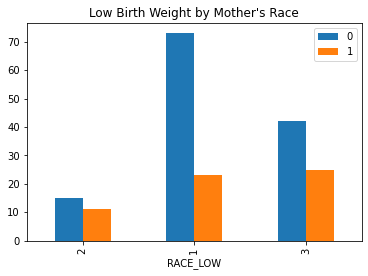

```python
#Low birth weight grouped by Race

import matplotlib.pyplot as plt
%matplotlib inline
df_data_1.crosstab('RACE', 'LOW').show()
df=df_data_1.crosstab('RACE', 'LOW').toPandas()
df.plot.bar(x="RACE_LOW", legend=True , title="Low Birth Weight by Mother's Race")
```

```
+-------+---+---+
|FTV_LOW|  0|  1|
+-------+---+---+
|      0| 64| 36|
|      1| 36| 11|
|      6|  1|  0|
|      2| 23|  7|
|      3|  3|  4|
|      4|  3|  1|
+-------+---+---+
```

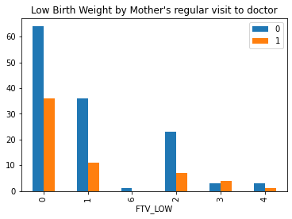

```python
#Low birth weight grouped by number of doctor's visit

import matplotlib.pyplot as plt
%matplotlib inline
df_data_1.crosstab('FTV', 'LOW').show()
df=df_data_1.crosstab('FTV', 'LOW').toPandas()
df.plot.bar(x="FTV_LOW", legend=True , title="Low Birth Weight by Mother's regular visit to doctor")
```

```
+---------+---+---+
|SMOKE_LOW|  0|  1|
+---------+---+---+
|        1| 44| 30|
|        0| 86| 29|
+---------+---+---+
```

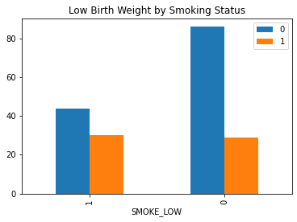

```python
#Low birth weight grouped by smoking status
import matplotlib.pyplot as plt
%matplotlib inline
df_data_1.crosstab('SMOKE', 'LOW').show()
df=df_data_1.crosstab('SMOKE', 'LOW').toPandas()
df.plot.bar(x="SMOKE_LOW", legend=True , title="Low Birth Weight by Smoking Status")
```

```python
# Average age by LOW outcome
# Convert Age data type from string to numeric.
pdf=df_data_1.toPandas()
pdf["AGE"]=pd.to_numeric(pdf.AGE)

df=sqlContext.createDataFrame(pdf)

PAge=df.groupby(['LOW'])\
.agg({"AGE": "AVG"}).toPandas()
PAge
```

|  | LOW | avg(AGE) |
| --- | --- | --- |
| 0 | 0 | 23.661538 |
| 1 | 1 | 22.305085 |

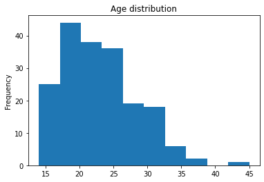

```python
#Age distribution for all mother
df.toPandas()["AGE"].plot.hist(x="Age", title="Age distribution")
```

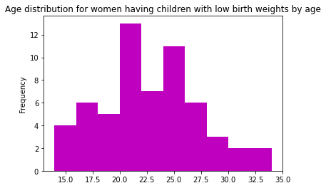

```python
# Age distribution for women having children with low birth weights by age.
df_died=df.select('AGE', 'LOW').filter(df['LOW']=='1')
pdf_died=df_died.select('AGE').toPandas()
pdf_died.plot.hist('AGE',  color='m',legend=False, title="Age distribution for women having children with low birth weights by age")
```

## Parse Data

Now let's load the data into a `Spark RDD` and output the number of rows and first 5 rows. Each project you create has a bucket in your object storage. You may get the bucket name from the project Settings page. Replace the string `BUCKET` to the bucket name

```python
data = sc.textFile(cos.url('lowbwt.csv', 'apachesparktutorial-donotdelete-pr-gzhhj3lfvqnwyl'))
print ("Total records in the data set:", data.count())
print ("The first 5 rows")
data.take(5)
```

```
Total records in the data set: 190
The first 5 rows
```

```
['ID,LOW,AGE,RACE,SMOKE,PTL,HT,UI,FTV',
 '85,0,19,2,0,0,0,1,0',
 '86,0,33,3,0,0,0,0,3',
 '87,0,20,1,1,0,0,0,1',
 '88,0,21,1,1,0,0,1,2']
```

Create DataFrame from RDD

```python
#Parse and Load the data into a dataframe. The code calls the parsing function defined above
documents = data.filter(lambda s: "Name" not in s).map(parseDocument)
lowbwtData = documents.toDF() # ToDataFrame
print ("Number of records: " + str(lowbwtData.count()))
print ( "First 5 records: ")
lowbwtData.take(5)
```

```
Number of records: 190
First 5 records:
```

```
[Row(ID='ID', PersonInfo='AGE RACE SMOKEPTL HTUI FTV', label=1.0),
 Row(ID='85', PersonInfo='19 2 00 01 0', label=0.0),
 Row(ID='86', PersonInfo='33 3 00 00 3', label=0.0),
 Row(ID='87', PersonInfo='20 1 10 00 1', label=0.0),
 Row(ID='88', PersonInfo='21 1 10 01 2', label=0.0)]
```

## Split Data into Training and Test set

We divide the data into training and test set. The training set is used to build the model to be used on future data, and the test set is used to evaluate the model.

```python
# Divide the data into training and test set, with random seed to reproduce results
(train, test) = lowbwtData.randomSplit([0.6, 0.4], seed = 123)
print ("Number of records in the training set: " + str(train.count()))
print ("Number of records in the test set: " + str(test.count()))
# Output first 20 records in the training set
print ("First 20 records in the training set: ")
train.show()
```

```
Number of records in the training set: 109
Number of records in the test set: 81
First 20 records in the training set:
+---+------------+-----+
| ID|  PersonInfo|label|
+---+------------+-----+
|100|18 1 10 00 0|  0.0|
|103|25 1 10 00 3|  0.0|
|104|20 3 00 01 0|  0.0|
|105|28 1 10 00 1|  0.0|
|107|31 1 00 01 3|  0.0|
|108|36 1 00 00 1|  0.0|
|111|25 3 00 01 2|  0.0|
|112|28 1 00 00 0|  0.0|
|115|26 2 10 00 0|  0.0|
|116|17 2 00 00 1|  0.0|
|117|17 2 00 00 1|  0.0|
|118|24 1 11 00 1|  0.0|
|120|25 1 00 00 1|  0.0|
|121|25 2 00 00 0|  0.0|
|123|29 1 10 00 2|  0.0|
|126|31 1 10 00 2|  0.0|
|127|33 1 10 00 1|  0.0|
|128|21 2 10 00 2|  0.0|
|130|23 2 00 00 1|  0.0|
|133|18 1 10 01 0|  0.0|
+---+------------+-----+
only showing top 20 rows
```

## Build Logistic Regression Model

We use the Pipeline of SparkML to build the Logistic Regression Model

```python
# set up Logistic Regression using Pipeline of SparkML
tokenizer = Tokenizer(inputCol="PersonInfo", outputCol="words")
hashingTF = HashingTF(inputCol=tokenizer.getOutputCol(), outputCol="features")
lr = LogisticRegression(maxIter=50, regParam=0.001)
pipeline = Pipeline(stages=[tokenizer, hashingTF, lr])
```

```python
# set up Logistic Regression Model
# the stages are executed in order
model = pipeline.fit(train)
#[stage.coefficients for stage in model.stages if hasattr(stage, "coefficients")]
# model.stages[2].intercept
model.stages[2].coefficients
```

```
SparseVector(262144, {4914: 0.5012, 12524: 0.6831, 15544: -3.2286, 25008: 1.4439, 44189: -3.3237, 44445: 0.0885, 46045: -0.4753, 52525: -1.2979, 73702: 1.4439, 76985: 0.1023, 87466: -0.2963, 87985: 0.2905, 90804: 0.2595, 92651: -0.608, 94522: -0.0995, 103775: 4.0311, 110130: 0.5996, 124674: -2.4578,…
```

## Predict for Test data

```python
# Make predictions for test data and print columns of interest
prediction = model.transform(test)
selected = prediction.select("PersonInfo", "prediction", "probability")
for row in selected.collect():
    print (row)
```

```
Row(PersonInfo='18 1 10 00 0', prediction=0.0, probability=DenseVector([0.9743, 0.0257]))
Row(PersonInfo='15 2 00 00 0', prediction=1.0, probability=DenseVector([0.0034, 0.9966]))
Row(PersonInfo='32 3 00 00 2', prediction=1.0, probability=DenseVector([0.0025, 0.9975]))
Row(PersonInfo='28 3 00 00 0', prediction=0.0, probability=DenseVector([0.9881, 0.0119]))
Row(PersonInfo='17 1 10 00 0', prediction=0.0, probability=DenseVector([0.7076, 0.2924]))
Row(PersonInfo='29 1 00 00 2', prediction=0.0, probability=DenseVector([0.8138, 0.1862]))
Row(PersonInfo='35 2 11 00 1', prediction=0.0, probability=DenseVector([0.6419, 0.3581]))
Row(PersonInfo='19 1 10 00 2', prediction=0.0, probability=DenseVector([0.5569, 0.4431]))
Row(PersonInfo='27 1 10 00 0', prediction=1.0, probability=DenseVector([0.0092, 0.9908]))
Row(PersonInfo='19 1 00 00 2', prediction=0.0, probability=DenseVector([0.7692, 0.2308]))
Row(PersonInfo='21 1 00 00 0', prediction=0.0, probability=DenseVector([0.9455, 0.0545]))
Row(PersonInfo='18 1 10 01 0', prediction=0.0, probability=DenseVector([0.9395, 0.0605]))
Row(PersonInfo='32 1 00 00 4', prediction=0.0, probability=DenseVector([0.685, 0.315]))
Row(PersonInfo='19 3 00 00 0', prediction=0.0, probability=DenseVector([0.6023, 0.3977]))
Row(PersonInfo='24 1 00 00 2', prediction=0.0, probability=DenseVector([0.8885, 0.1115]))
Row(PersonInfo='22 3 10 00 0', prediction=0.0, probability=DenseVector([0.819, 0.181]))
Row(PersonInfo='22 1 10 00 0', prediction=0.0, probability=DenseVector([0.9468, 0.0532]))
Row(PersonInfo='19 3 00 00 0', prediction=0.0, probability=DenseVector([0.6023, 0.3977]))
Row(PersonInfo='21 3 10 01 0', prediction=1.0, probability=DenseVector([0.4049, 0.5951]))
Row(PersonInfo='17 3 00 00 0', prediction=0.0, probability=DenseVector([0.62, 0.38]))
Row(PersonInfo='17 3 00 00 0', prediction=0.0, probability=DenseVector([0.62, 0.38]))
Row(PersonInfo='23 3 00 00 2', prediction=0.0, probability=DenseVector([0.6267, 0.3733]))
Row(PersonInfo='24 3 00 00 2', prediction=0.0, probability=DenseVector([0.6695, 0.3305]))
Row(PersonInfo='22 2 01 00 2', prediction=0.0, probability=DenseVector([0.7483, 0.2517]))
Row(PersonInfo='31 3 10 00 2', prediction=0.0, probability=DenseVector([0.983, 0.017]))
Row(PersonInfo='23 3 10 00 1', prediction=0.0, probability=DenseVector([0.6971, 0.3029]))
Row(PersonInfo='16 1 10 00 0', prediction=0.0, probability=DenseVector([0.7014, 0.2986]))
Row(PersonInfo='18 2 00 00 0', prediction=0.0, probability=DenseVector([0.9651, 0.0349]))
Row(PersonInfo='32 1 11 00 4', prediction=1.0, probability=DenseVector([0.0191, 0.9809]))
Row(PersonInfo='20 2 10 00 0', prediction=0.0, probability=DenseVector([0.5077, 0.4923]))
Row(PersonInfo='32 1 00 00 0', prediction=1.0, probability=DenseVector([0.0173, 0.9827]))
Row(PersonInfo='19 3 00 00 0', prediction=0.0, probability=DenseVector([0.6023, 0.3977]))
Row(PersonInfo='23 1 00 00 0', prediction=0.0, probability=DenseVector([0.9219, 0.0781]))
Row(PersonInfo='21 3 00 00 2', prediction=0.0, probability=DenseVector([0.7115, 0.2885]))
Row(PersonInfo='19 2 00 01 0', prediction=1.0, probability=DenseVector([0.4014, 0.5986]))
Row(PersonInfo='33 3 00 00 3', prediction=0.0, probability=DenseVector([0.9804, 0.0196]))
Row(PersonInfo='22 1 00 00 1', prediction=0.0, probability=DenseVector([0.9897, 0.0103]))
Row(PersonInfo='17 3 00 00 1', prediction=0.0, probability=DenseVector([0.7685, 0.2315]))
Row(PersonInfo='30 3 01 01 2', prediction=0.0, probability=DenseVector([0.5031, 0.4969]))
Row(PersonInfo='25 3 01 10 0', prediction=1.0, probability=DenseVector([0.1637, 0.8363]))
```

[output cut: 26 more lines]

```
Row(PersonInfo='27 2 00 01 0', prediction=1.0, probability=DenseVector([0.0028, 0.9972]))
Row(PersonInfo='17 1 10 00 0', prediction=0.0, probability=DenseVector([0.7076, 0.2924]))
Row(PersonInfo='18 3 00 00 0', prediction=0.0, probability=DenseVector([0.9624, 0.0376]))
Row(PersonInfo='21 3 01 00 4', prediction=0.0, probability=DenseVector([0.9955, 0.0045]))
Row(PersonInfo='31 1 11 00 1', prediction=0.0, probability=DenseVector([0.9514, 0.0486]))
Row(PersonInfo='23 2 10 00 1', prediction=0.0, probability=DenseVector([0.7135, 0.2865]))
Row(PersonInfo='24 2 10 00 0', prediction=0.0, probability=DenseVector([0.5963, 0.4037]))
Row(PersonInfo='22 1 10 00 1', prediction=0.0, probability=DenseVector([0.9731, 0.0269]))
Row(PersonInfo='23 1 11 00 0', prediction=1.0, probability=DenseVector([0.0956, 0.9044]))
Row(PersonInfo='26 3 01 10 1', prediction=1.0, probability=DenseVector([0.3611, 0.6389]))
Row(PersonInfo='20 3 00 00 3', prediction=0.0, probability=DenseVector([0.5667, 0.4333]))
Row(PersonInfo='28 1 10 00 2', prediction=0.0, probability=DenseVector([0.9856, 0.0144]))
Row(PersonInfo='14 3 00 00 2', prediction=0.0, probability=DenseVector([0.7468, 0.2532]))
Row(PersonInfo='23 3 10 00 0', prediction=0.0, probability=DenseVector([0.5308, 0.4692]))
Row(PersonInfo='17 2 00 10 0', prediction=1.0, probability=DenseVector([0.3996, 0.6004]))
```

```python
#Tabulate the predicted outcome
prediction.select("prediction").groupBy("prediction").count().show(truncate=False)
```

```
+----------+-----+
|prediction|count|
+----------+-----+
|0.0       |63   |
|1.0       |18   |
+----------+-----+
```

```python
#Tabulate the actual outcome
prediction.select("label").groupBy("label").count().show(truncate=False)
```

```
+-----+-----+
|label|count|
+-----+-----+
|0.0  |57   |
|1.0  |24   |
+-----+-----+
```

```python
# This table shows:
# 1. The number of low birth weight infants predicted as having low birth weight
# 2. The number of low birth weight infants predicted as not having low birth weight
# 3. The number of regular birth weight infants predicted as having low birth weight
# 4. The number of regular birth weight infants predicted as not having low birth weight

prediction.crosstab('label', 'prediction').show()
```

```
+----------------+---+---+
|label_prediction|0.0|1.0|
+----------------+---+---+
|             1.0| 16|  8|
|             0.0| 47| 10|
+----------------+---+---+
```

## Evaluate the Model

We evaluate the model on a training set and on a test set. The purpose is to measure the model's predictive accuracy, including the accuracy for new data.

```python
# Evaluate the Logistic Regression model on a training set
# Select (prediction, true label) and compute test error
pred_lr=model.transform(train).select("prediction", "label")
eval_lr=MulticlassClassificationEvaluator (
    labelCol="label", predictionCol="prediction", metricName="accuracy")
accuracy_lr=eval_lr.evaluate(pred_lr)
# create RDD
predictionAndLabels_lr=pred_lr.rdd
metrics_lr=MulticlassMetrics(predictionAndLabels_lr)
precision_lr=metrics_lr.precision(1.0)
recall_lr=metrics_lr.recall(1.0)
f1Measure_lr = metrics_lr.fMeasure(1.0, 1.0)
print ("Model evaluation for the training data")
print ("Accuracy = %s" %accuracy_lr)
print ("Error = %s" % (1-accuracy_lr))
print ("Precision = %s" %precision_lr)
print ("Recall = %s" %recall_lr)
print("F1 Measure = %s" % f1Measure_lr)
```

```
Model evaluation for the training data
Accuracy = 0.7614678899082569
Error = 0.23853211009174313
Precision = 0.6923076923076923
Recall = 0.5
F1 Measure = 0.5806451612903226
```

```python
# Evaluate the Logistic Regression model on a test set
# Select (prediction, true label) and compute test error
pred_lr=model.transform(test).select("prediction", "label")
eval_lr=MulticlassClassificationEvaluator (
    labelCol="label", predictionCol="prediction", metricName="accuracy")
accuracy_lr=eval_lr.evaluate(pred_lr)
# create RDD
predictionAndLabels_lr=pred_lr.rdd
metrics_lr=MulticlassMetrics(predictionAndLabels_lr)
precision_lr=metrics_lr.precision(1.0)
recall_lr=metrics_lr.recall(1.0)
f1Measure_lr = metrics_lr.fMeasure(1.0, 1.0)
print ("Model evaluation for the test data")
print ("Accuracy = %s" %accuracy_lr)
print ("Error = %s" % (1-accuracy_lr))
print ("Precision = %s" %precision_lr)
print ("Recall = %s" %recall_lr)
print ("F1 Measure = %s" % f1Measure_lr)
```

```
Model evaluation for the test data
Accuracy = 0.6790123456790124
Error = 0.32098765432098764
Precision = 0.4444444444444444
Recall = 0.3333333333333333
F1 Measure = 0.380952380952381
```

```python
bin_lr=BinaryClassificationMetrics(predictionAndLabels_lr)

# Area under precision-recall curve
print("Area under PR = %s" % bin_lr.areaUnderPR)
# Area under Receiver operating characteristic curve
print("Area under ROC = %s" % bin_lr.areaUnderROC)
```

```
Area under PR = 0.3950617283950617
Area under ROC = 0.5789473684210527
```

## ROC Curve Plot

The Binary Logistic Regression method returns the pyspark.ml.classification.BinaryLogisticRegressionTrainingSummary object. We may use the roc method to obtain the coordinates of the points on Receiver operating characteristic (ROC) curve. The coordinates are stored in a Dataframe with two fields FPR=false positive rate and TPR=true positive rate

```python
#The firt 20 ROC curve points
model.stages[2].summary.roc.show()
```

```
+------------------+--------------------+
|               FPR|                 TPR|
+------------------+--------------------+
|               0.0|                 0.0|
|               0.0|0.027777777777777776|
|               0.0| 0.05555555555555555|
|               0.0| 0.08333333333333333|
|               0.0|  0.1111111111111111|
|               0.0|  0.1388888888888889|
|               0.0| 0.16666666666666666|
|               0.0| 0.19444444444444445|
|               0.0|  0.2222222222222222|
|               0.0|                0.25|
|               0.0|  0.2777777777777778|
|0.0136986301369863|  0.2777777777777778|
|0.0273972602739726|  0.2777777777777778|
|0.0273972602739726|  0.3055555555555556|
|0.0273972602739726|  0.3333333333333333|
|0.0273972602739726|  0.3611111111111111|
|0.0273972602739726|  0.3888888888888889|
|0.0273972602739726|  0.4166666666666667|
|0.0273972602739726|  0.4444444444444444|
|0.0410958904109589|  0.4444444444444444|
+------------------+--------------------+
only showing top 20 rows
```

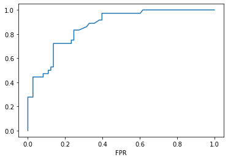

```python
import matplotlib.pyplot as plt
%matplotlib inline
ROC=model.stages[2].summary.roc
df=ROC.toPandas()

df.plot(x='FPR', y='TPR', legend=False)
```